# Lecture 11

2022-10-11

## More Data Visualization

## Data visualization

- Need to communicate your understanding to others
- Your audience will likely not share your background knowledge and will not be deeply invested in the data.
- To help others build a good mental model of the data you need to invest considerable effort in making your plots as self=explanatory as possible.

## Label

The easiest place to start when turning an *exploratory* graphic into an *expository* graphic is with good labels.

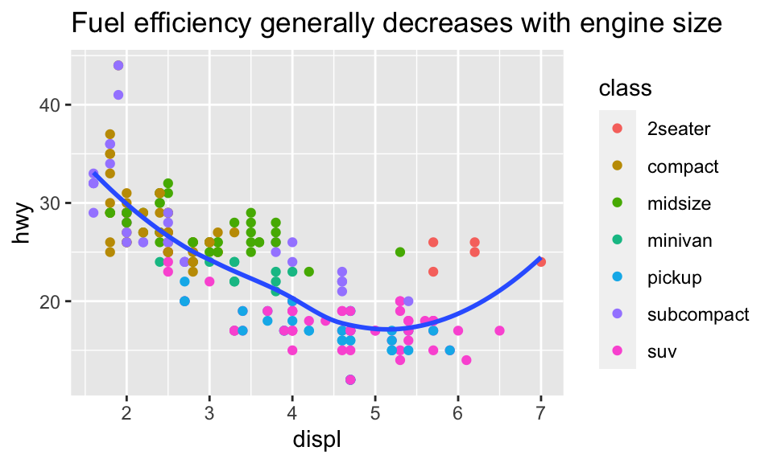

```r
ggplot(mpg, aes(displ, hwy)) +
  geom_point(aes(color = class)) +
  geom_smooth(se = FALSE)+
   labs(title = "Fuel efficiency generally decreases with engine size")
```

## Useful text layers

- `subtitle` adds additional detail in a smaller font beneath the title.
- `caption` adds text at the bottom right of the plot, often used to describe the source of the data.

```r
ggplot(mpg, aes(displ, hwy)) +
geom_point(aes(color = class)) +
geom_smooth(se = FALSE) +
labs(
  title = "Fuel efficiency generally decreases with engine size",
  subtitle = "Two seaters (sports cars) are an exception because of their light weight",
  caption = "Data from fueleconomy.gov"
)
```

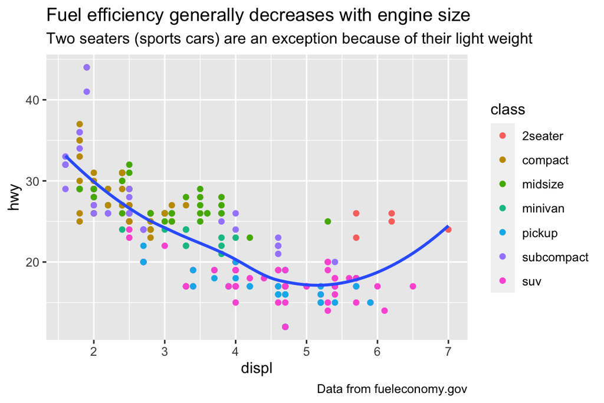

```r
ggplot(mpg, aes(displ, hwy)) +
geom_point(aes(color = class)) +
geom_smooth(se = FALSE) +
labs(
  title = "Fuel efficiency generally decreases with engine size",
  subtitle = "Two seaters (sports cars) are an exception because of their light weight",
  caption = "Data from fueleconomy.gov"
)
```

## `labs()`

- You can also use `labs()` to replace the axis and legend titles.
- Useful to:
  - Replace short variable names with more detailed descriptions
  - Include units

```r
ggplot(mpg, aes(displ, hwy)) +
  geom_point(aes(color = class)) +
  geom_smooth(se = FALSE) +
  labs(
    x = "Engine displacement (L)",
    y = "Highway fuel economy (mpg)",
    color = "Car type"
  )
```

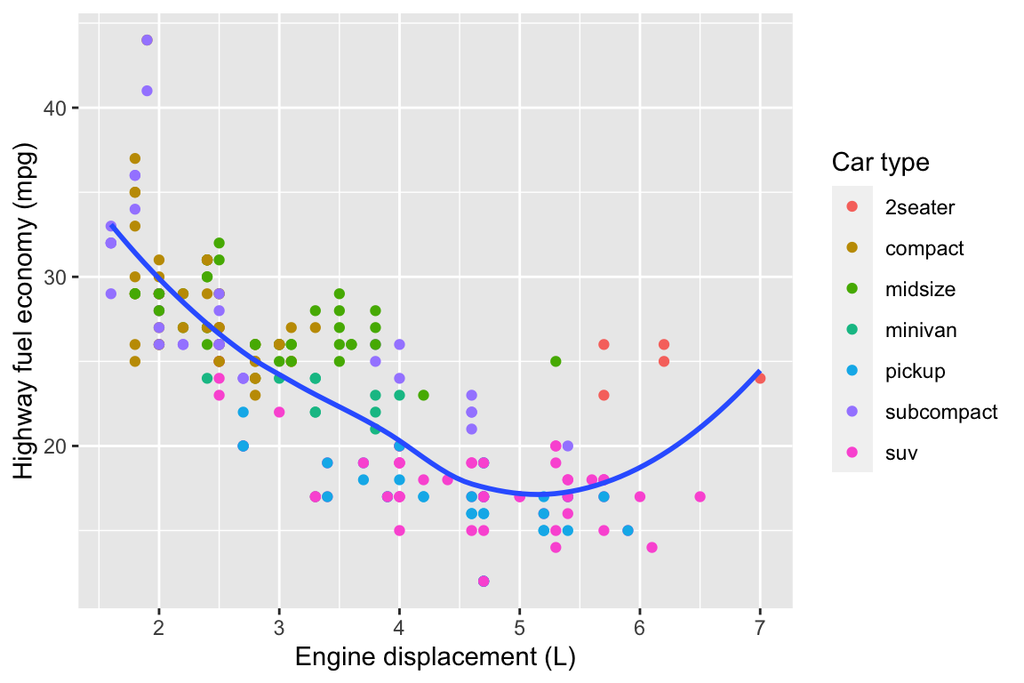

```r
ggplot(mpg, aes(displ, hwy)) +
  geom_point(aes(color = class)) +
  geom_smooth(se = FALSE) +
  labs(
    x = "Engine displacement (L)",
    y = "Highway fuel economy (mpg)",
    color = "Car type"
  )
```

## Mathematical Equations

It’s possible to use mathematical equations instead of text strings.  
Switch “” out for `quote()` and read about available options in `?plotmath`

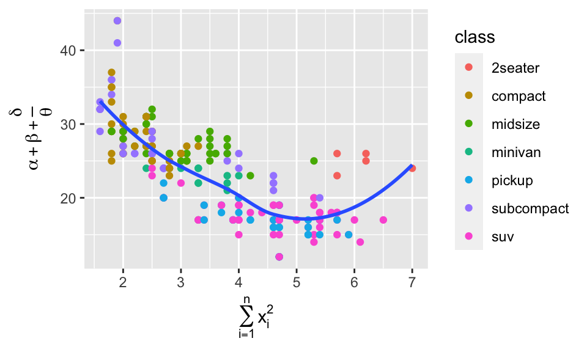

```r
ggplot(mpg, aes(displ, hwy)) +
  geom_point(aes(color = class)) +
  geom_smooth(se = FALSE)+
  labs(
    x = quote(sum(x[i] ^ 2, i == 1, n)),
    y = quote(alpha + beta + frac(delta, theta))
  )
```

## Your turn

- Create one plot using `diamonds` or `mgg` data with customized `title`, `subtitle`, `x`, `y`, and `color` labels.

## Annotations

- It can also be useful to label individual observations or groups of observations.
- You can use `geom_text()` or `geom_label()`.
  - Similar to `geom_point()` but have an additional aesthetic: `label`
  - `geom_text()` adds text directly to the plot
  - `geom_label()` draws a rectangle behind the text, making it easier to read.

## Example of `geom_label()`

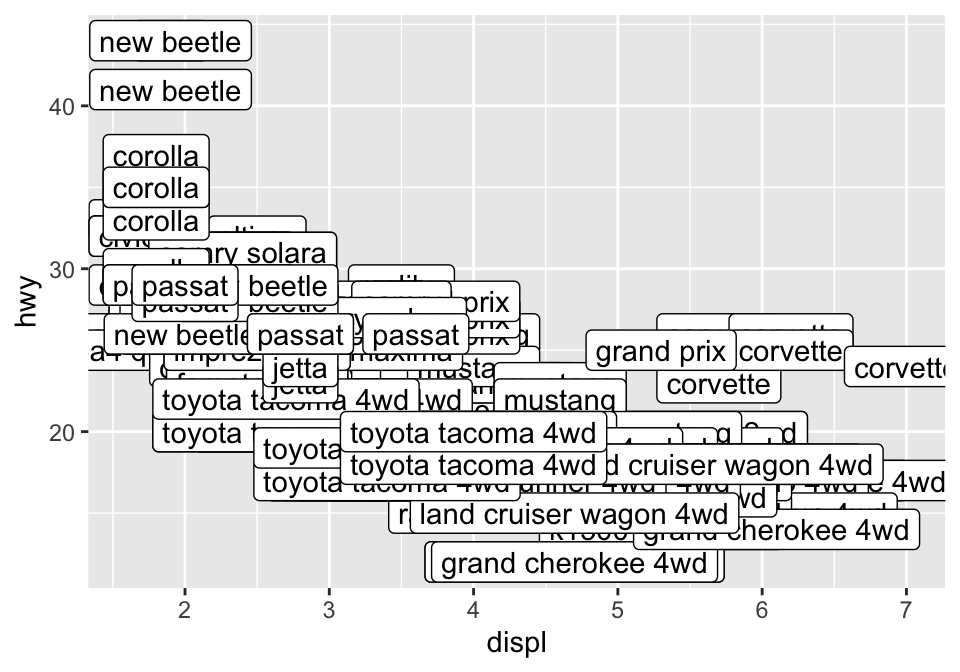

```r
ggplot(mpg, aes(x= displ, y=hwy)) +
  geom_label(aes(label=model))
```

Messy to label all of the points like this, what might be a better way to use this feature?

## Example of `geom_label()`

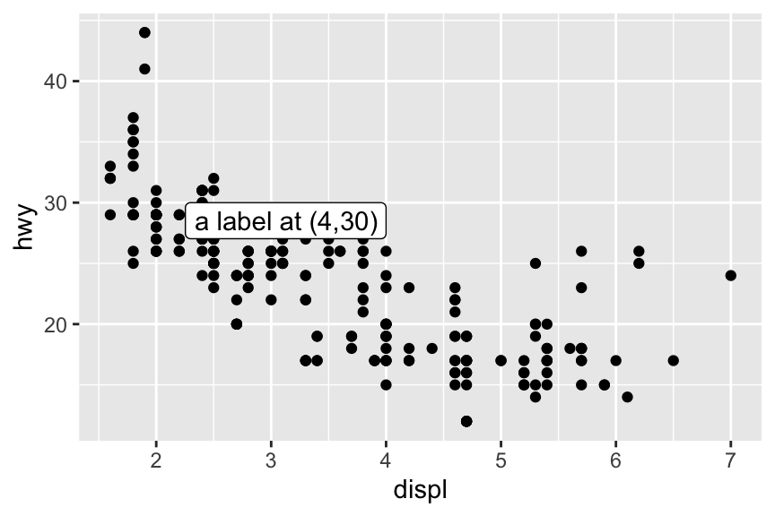

```r
  mpg_label <- tibble(
  displ = 4,
  hwy = 30,
  label = "a label at (4,30)"
)

ggplot(mpg, aes(x= displ, y=hwy)) +
  geom_point() +
  geom_label(data = mpg_label, aes(label=label),vjust = "top", hjust = "right")
```

## More labeling

- If you want to place the text exactly on the borders of the plot, you can use `+Inf` and `-Inf`
- Use hjust and vjust to control the alignment of the label.
- You have many other geoms in ggplot2 to help annotate your plot.
  - Use `geom_rect()` to draw a rectangle around points of interest.
  - The boundaries of the rectangle are defined by aesthetics `xmin`, `xmax`, `ymin`, `ymax`.
  - Use `geom_segment()` with the arrow argument to draw attention to a point with an arrow.
    - Use aesthetics `x` and `y` to define the starting location, and `xend` and `yend` to define the end location.

## Your turn

- Use `geom_text()` with infinite positions to place text at the four corners of the plot.
- How do labels with `geom_text()` interact with faceting?
  - How can you add a label to a single facet?
  - How can you put a different label in each facet?
  - (Hint: think about the underlying data)
- Try `geom_segment()` to add an arrow to your plot

## Scales

- Scales control the mapping from data values to things that you can perceive.
- Normally, ggplot2 automatically adds scales for you.

```r
ggplot(mpg, aes(displ, hwy)) +
  geom_point(aes(color = class)) +
  scale_x_continuous() +
  scale_y_continuous() +
 scale_color_discrete()
```

Note the naming scheme for scales: `scale_` followed by the name of the aesthetic, then `_`, then the type of scale: continuous, discrete, datetime, or date.

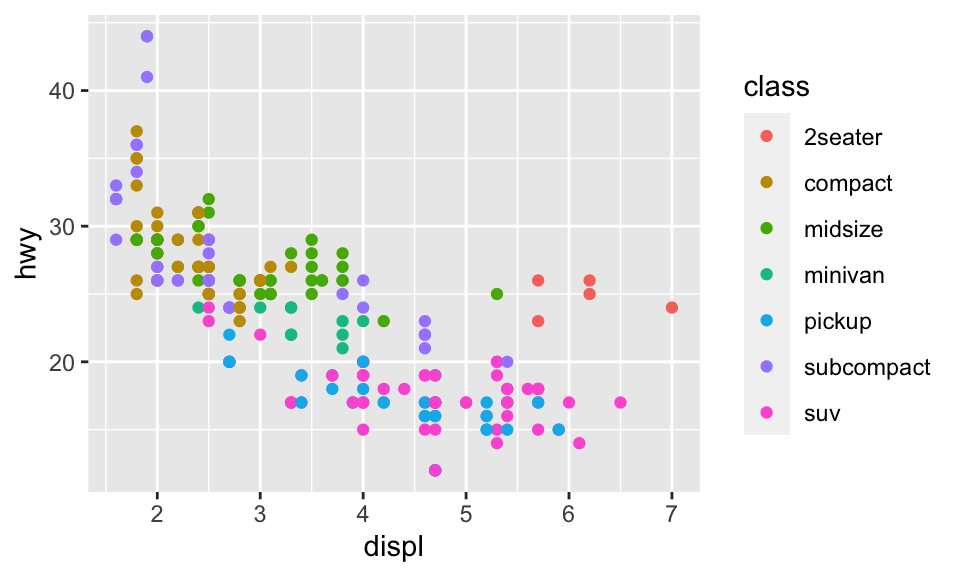

```r
ggplot(mpg, aes(displ, hwy)) +
  geom_point(aes(color = class)) +
  scale_x_continuous() +
  scale_y_continuous() +
 scale_color_discrete()
```

## Axis ticks and legend keys

- There are 2 primary arguments that affect the appearance of the ticks/labels on the axes, and the keys on the legend
  - `breaks` controls the position of the ticks, or values associated with the keys
  - `labels` controls the text labels associated with each tick/key.

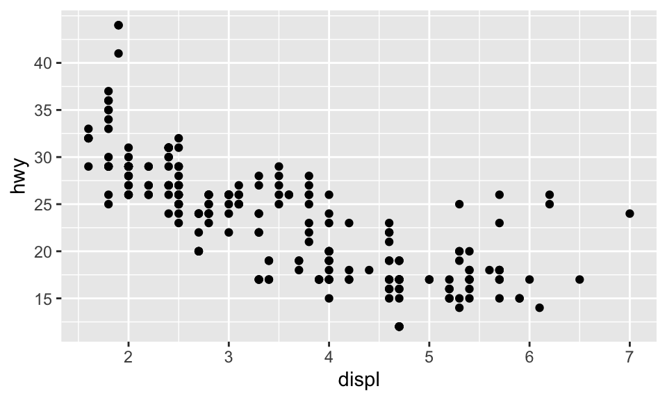

```r
ggplot(mpg, aes(displ, hwy)) +
geom_point() +
scale_y_continuous(breaks = seq(15, 40, by = 5))
```

You can use labels in the same way (a character vector the same length as breaks)

You can also set `labels` to `NULL` to suppress labels all together

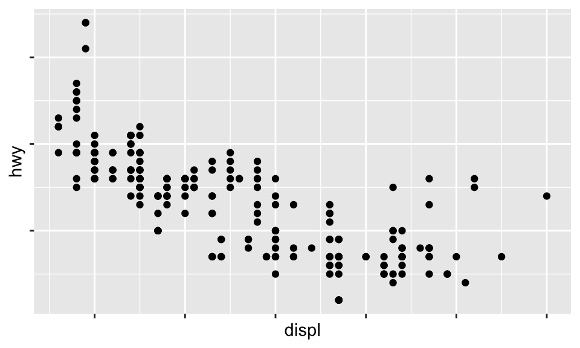

```r
ggplot(mpg, aes(displ, hwy)) +
geom_point() +
scale_x_continuous(labels = NULL) +
scale_y_continuous(labels = NULL)
```

## Legend layout

To control the overall position of the legend, you need to use a theme() setting. In brief, it controls the non-data parts of the plot.

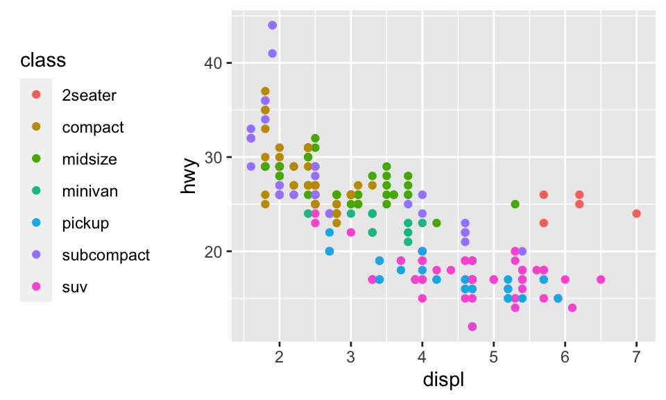

```r
base <- ggplot(mpg, aes(displ, hwy)) +
  geom_point(aes(color = class))

base + theme(legend.position = "left")
```

Or you can put the legend inside the plot…

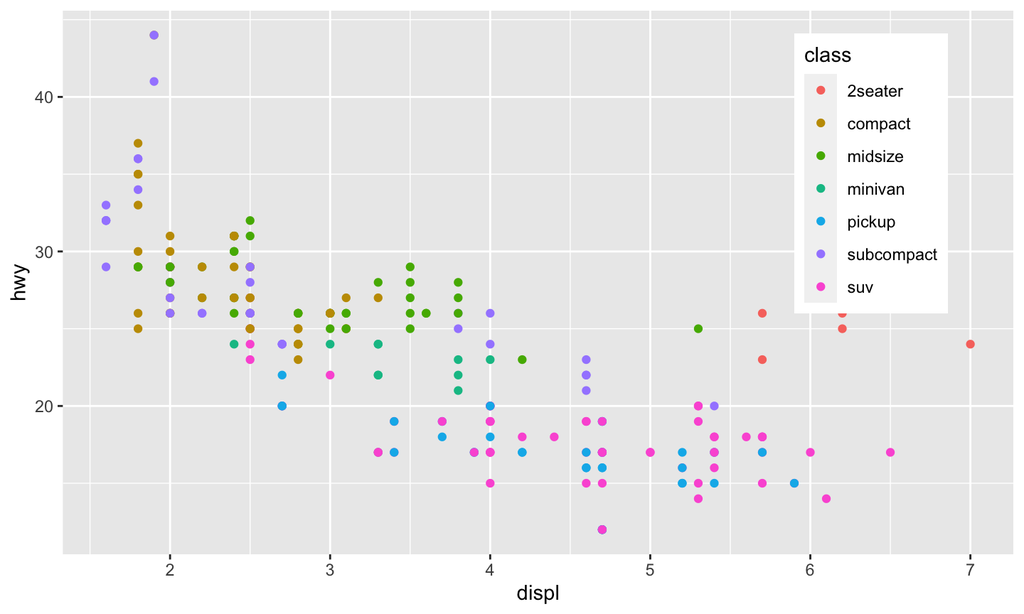

```r
base + theme(legend.position = c(.85, .7))
```

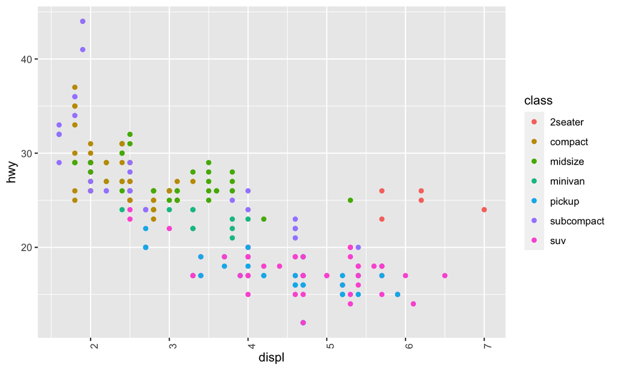

```r
base + theme(axis.text.x = element_text(angle = 90))
```

You can also use `legend.position = "none"` to suppress the display of the legend.

To control the display of individual legends, use `guides()` along with `guide_legend()` or `guide_colorbar()`.

[figure not shown]

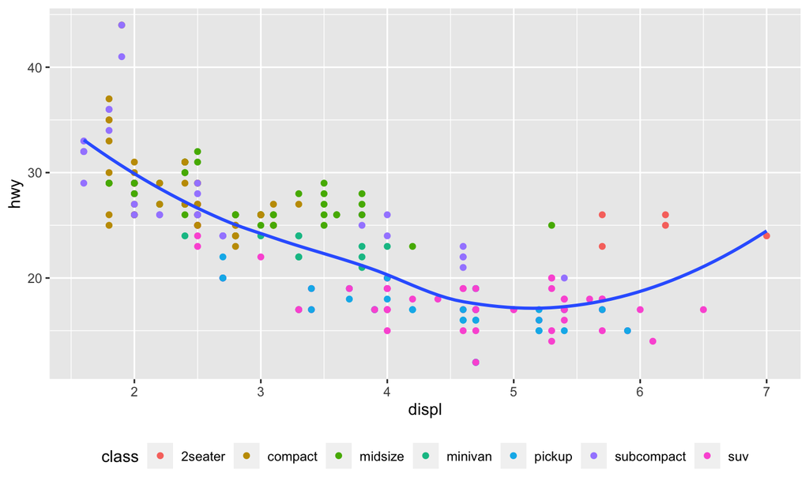

```r
ggplot(mpg, aes(displ, hwy)) +
  geom_point(aes(color = class)) +
  geom_smooth(se = FALSE) +
  theme(legend.position = "bottom") +
  guides(color = guide_legend(nrow = 1))
```

## Your turn

- Move the legend to the bottom (1 row), change the scale of `y` from 10 to 50 and the scale of `x` from 1 to 10. (Check `limits` argument if you find `breaks` does not work)

```r
ggplot(mpg, aes(displ, hwy)) +
  geom_point(aes(color = class))
```